# Predicting Stock Prices and Asset Bubbles Using Deep Learning: A Case Study of Nvidia

### News Data preprocessing

This dataset contains selected financial news articles related to NVIDIA from Yahoo and X (Twitter) between August 2015 and June 2024. The collection and compilation of this dataset focuses on capturing key financial news, market performance insights, strategic business initiatives, and technological advancements that impact these companies. The data covers a range of release dates, providing a temporal view of major events and their potential impact on the market and company valuations.

The financial news data is fed into a hybrid deep learning model to extract three main features: sentiment analysis, news volume, and event impact. These features are valuable because they reflect market sentiment, investor behavior, and major events that may affect stock prices.

```python
nvidia_sentimental_analisis= pd.read_csv('nvidia_sentimental_analisis.csv')
```

```python
print(nvidia_news_analisis.head())
print(nvidia_news_analisis.info())
print(nvidia_news_analisis['sentiment_rf'].value_counts())
print(nvidia_news_analisis['sentiment_nn'].value_counts())
```

```
         Date                                            Summary sentiment_rf  \
0  2024-06-14  As bolsas de Nova York fecharam sem direção ún...      neutral
1  2024-06-14  Os futuros dos índices de ações dos EUA tivera...     positive
2  2024-06-14  Os acionistas da Tesla (NASDAQ:TSLA) mostraram...      neutral
3  2024-06-13  Em um movimento recente, Mark A. Stevens, dire...      neutral
4  2024-06-13  (Bloomberg) -- A Broadcom experimentou uma alt...      neutral

  sentiment_nn
0     positive
1     positive
2      neutral
3      neutral
4      neutral
<class 'pandas.core.frame.DataFrame'>
RangeIndex: 911 entries, 0 to 910
Data columns (total 4 columns):
 #   Column        Non-Null Count  Dtype
---  ------        --------------  -----
 0   Date          911 non-null    object
 1   Summary       911 non-null    object
 2   sentiment_rf  911 non-null    object
 3   sentiment_nn  911 non-null    object
dtypes: object(4)
memory usage: 28.6+ KB
None
sentiment_rf
neutral     394
negative    309
positive    208
Name: count, dtype: int64
sentiment_nn
neutral     774
positive    109
negative     28
Name: count, dtype: int64
```

### S&P 500 Stocks

The Standard and Poor's 500 or S&P 500 is the most famous financial benchmark in the world.

This stock market index tracks the performance of 500 large companies listed on stock exchanges in the United States. As of December 31, 2020, more than $5.4 trillion was invested in assets tied to the performance of this index.

Because the index includes multiple classes of stock of some constituent companies—for example, Alphabet's Class A (GOOGL) and Class C (GOOG)—there are actually 505 stocks in the gauge.

```python
sp500_companies= pd.read_csv('sp500_companies.csv')
sp500_index= pd.read_csv('sp500_index.csv')
sp500_stocks= pd.read_csv('sp500_stocks.csv')
```

```python
sp500_companies.head()
```

|  | Exchange | Symbol | Shortname | Longname | Sector | Industry | Currentprice | Marketcap | Ebitda | Revenuegrowth | City | State | Country | Fulltimeemployees | Longbusinesssummary | Weight |
| --- | --- | --- | --- | --- | --- | --- | --- | --- | --- | --- | --- | --- | --- | --- | --- | --- |
| 0 | NMS | AAPL | Apple Inc. | Apple Inc. | Technology | Consumer Electronics | 226.49 | 3443576799232 | 1.317810e+11 | 0.049 | Cupertino | CA | United States | 161000.0 | Apple Inc. designs, manufactures, and markets ... | 0.066324 |
| 1 | NMS | NVDA | NVIDIA Corporation | NVIDIA Corporation | Technology | Semiconductors | 125.61 | 3089792499712 | 4.927500e+10 | 2.621 | Santa Clara | CA | United States | 29600.0 | NVIDIA Corporation provides graphics and compu... | 0.059510 |
| 2 | NMS | MSFT | Microsoft Corporation | Microsoft Corporation | Technology | Software - Infrastructure | 410.60 | 3052006277120 | 1.294330e+11 | 0.152 | Redmond | WA | United States | 228000.0 | Microsoft Corporation develops and supports so... | 0.058782 |
| 3 | NMS | GOOGL | Alphabet Inc. | Alphabet Inc. | Communication Services | Internet Content & Information | 162.85 | 2014080008192 | 1.154780e+11 | 0.136 | Mountain View | CA | United States | 179582.0 | Alphabet Inc. offers various products and plat... | 0.038791 |
| 4 | NMS | GOOG | Alphabet Inc. | Alphabet Inc. | Communication Services | Internet Content & Information | 164.50 | 2013693870080 | 1.154780e+11 | 0.136 | Mountain View | CA | United States | 179582.0 | Alphabet Inc. offers various products and plat... | 0.038784 |

```python
sp500_index.head()
```

|  | Date | S&P500 |
| --- | --- | --- |
| 0 | 2014-08-28 | 1996.74 |
| 1 | 2014-08-29 | 2003.37 |
| 2 | 2014-09-02 | 2002.28 |
| 3 | 2014-09-03 | 2000.72 |
| 4 | 2014-09-04 | 1997.65 |

```python
sp500_stocks.head()
```

|  | Date | Symbol | Adj Close | Close | High | Low | Open | Volume |
| --- | --- | --- | --- | --- | --- | --- | --- | --- |
| 0 | 2010-01-04 | MMM | 44.016739 | 69.414719 | 69.774246 | 69.122070 | 69.473244 | 3640265.0 |
| 1 | 2010-01-05 | MMM | 43.741013 | 68.979935 | 69.590302 | 68.311035 | 69.230766 | 3405012.0 |
| 2 | 2010-01-06 | MMM | 44.361351 | 69.958191 | 70.735786 | 69.824417 | 70.133781 | 6301126.0 |
| 3 | 2010-01-07 | MMM | 44.393166 | 70.008362 | 70.033447 | 68.662209 | 69.665550 | 5346240.0 |
| 4 | 2010-01-08 | MMM | 44.705978 | 70.501671 | 70.501671 | 69.648827 | 69.974915 | 4073337.0 |

```python
sp500_stocks_describe = sp500_stocks.describe()
sp500_stocks_describe
```

|  | Adj Close | Close | High | Low | Open | Volume |
| --- | --- | --- | --- | --- | --- | --- |
| count | 1.760185e+06 | 1.760185e+06 | 1.760185e+06 | 1.760185e+06 | 1.760185e+06 | 1.760185e+06 |
| mean | 9.688248e+01 | 1.039017e+02 | 1.050390e+02 | 1.027081e+02 | 1.038817e+02 | 6.961952e+06 |
| std | 2.064002e+02 | 2.065282e+02 | 2.089303e+02 | 2.040465e+02 | 2.064398e+02 | 3.316481e+07 |
| min | 9.377111e-02 | 2.220000e-01 | 2.262500e-01 | 2.162500e-01 | 2.180000e-01 | 0.000000e+00 |
| 25% | 2.920133e+01 | 3.488000e+01 | 3.525465e+01 | 3.447818e+01 | 3.487000e+01 | 9.984000e+05 |
| 50% | 5.409850e+01 | 6.234902e+01 | 6.297000e+01 | 6.167000e+01 | 6.232000e+01 | 2.178500e+06 |
| 75% | 1.031645e+02 | 1.128000e+02 | 1.139700e+02 | 1.115800e+02 | 1.128000e+02 | 4.997300e+06 |
| max | 9.321270e+03 | 9.321270e+03 | 9.360000e+03 | 9.122310e+03 | 9.325000e+03 | 3.692928e+09 |

### Historical 3-month Treasury Bill Rates (2000-2023)

This dataset contains historical 3-month Treasury Bill rates, sourced from Yahoo Finance. The dataset spans from January 3, 2000, to December 31, 2023, and provides daily prices along with adjusted close prices and volumes. This data is crucial for financial analysts, economists, and researchers who are interested in interest rate trends and their impact on the economy.

```python
Historical_3m_treasury_bill_interest_rates= pd.read_csv('3m_treasury_bill_interest_rates.csv')
```

```python
Historical_3m_treasury_bill_interest_rates.head()
```

|  | Date | Open | High | Low | Close | Adj Close | Volume |
| --- | --- | --- | --- | --- | --- | --- | --- |
| 0 | 2000-01-03 | 5.23 | 5.30 | 5.23 | 5.27 | 5.27 | 0 |
| 1 | 2000-01-04 | 5.29 | 5.29 | 5.27 | 5.27 | 5.27 | 0 |
| 2 | 2000-01-05 | 5.30 | 5.30 | 5.26 | 5.27 | 5.27 | 0 |
| 3 | 2000-01-06 | 5.26 | 5.27 | 5.24 | 5.24 | 5.24 | 0 |
| 4 | 2000-01-07 | 5.25 | 5.28 | 5.22 | 5.22 | 5.22 | 0 |

```python
Historical_3m_treasury_bill_interest_rates_describe = Historical_3m_treasury_bill_interest_rates.describe()
Historical_3m_treasury_bill_interest_rates_describe
```

|  | Open | High | Low | Close | Adj Close | Volume |
| --- | --- | --- | --- | --- | --- | --- |
| count | 6031.000000 | 6031.000000 | 6031.000000 | 6031.000000 | 6031.000000 | 6031.000000 |
| mean | 1.655933 | 1.668397 | 1.639263 | 1.653750 | 1.653750 | 1164.085558 |
| std | 1.841710 | 1.847079 | 1.833378 | 1.840755 | 1.840755 | 13453.474654 |
| min | -0.108000 | -0.100000 | -0.235000 | -0.105000 | -0.105000 | 0.000000 |
| 25% | 0.090000 | 0.093000 | 0.083000 | 0.088000 | 0.088000 | 0.000000 |
| 50% | 0.998000 | 1.010000 | 0.985000 | 0.998000 | 0.998000 | 0.000000 |
| 75% | 2.528500 | 2.547000 | 2.480000 | 2.527000 | 2.527000 | 0.000000 |
| max | 6.210000 | 6.230000 | 6.210000 | 6.220000 | 6.220000 | 159700.000000 |

### US_Recession data

This dataset includes various economic indicators such as stock market performance, inflation rates, GDP, interest rates, employment data, and housing index, all of which are crucial for understanding the state of the economy. By analysing this dataset, one can gain insights into the causes and effects of past recessions in the US, which can inform investment decisions and policy-making.

```python
US_Recession= pd.read_csv('US_Recession.csv')
```

```python
US_Recession.head()
```

|  | Unnamed: 0 | Price_x | INDPRO | CPI | 3 Mo | 4 Mo | 6 Mo | 1 Yr | 2 Yr | 3 Yr | 5 Yr | 7 Yr | 10 Yr | 20 Yr | 30 Yr | GDP | Rate | BBK_Index | Housing_Index | Recession |
| --- | --- | --- | --- | --- | --- | --- | --- | --- | --- | --- | --- | --- | --- | --- | --- | --- | --- | --- | --- | --- |
| 0 | 0 | 0.007111 | 0.046856 | 0.000000 | 1.000000 | 0.0 | 1.000000 | 1.000000 | 1.000000 | 1.000000 | 1.000000 | 0.995788 | 0.981235 | 0.0 | 0.957474 | 0.00000 | 0.996359 | 0.463980 | 0.008161 | 0 |
| 1 | 1 | 0.009875 | 0.051140 | 0.001183 | 0.996264 | 0.0 | 0.991458 | 0.984958 | 0.987719 | 0.986550 | 0.998219 | 0.993983 | 0.976998 | 0.0 | 0.953608 | 0.00000 | 0.986650 | 0.449089 | 0.009267 | 0 |
| 2 | 2 | 0.012196 | 0.055858 | 0.005914 | 0.993773 | 0.0 | 0.976205 | 0.967509 | 0.962573 | 0.963743 | 0.969121 | 0.968712 | 0.950363 | 0.0 | 0.926546 | 0.00000 | 1.000000 | 0.422505 | 0.010159 | 0 |
| 3 | 3 | 0.012114 | 0.053475 | 0.009463 | 0.976339 | 0.0 | 0.960342 | 0.943442 | 0.938012 | 0.946199 | 0.956057 | 0.961492 | 0.951574 | 0.0 | 0.934278 | 0.00273 | 0.983010 | 0.397466 | 0.010395 | 0 |
| 4 | 4 | 0.005410 | 0.058643 | 0.015968 | 0.957659 | 0.0 | 0.939597 | 0.927798 | 0.930994 | 0.943860 | 0.971496 | 0.985560 | 0.987893 | 0.0 | 0.985825 | 0.00273 | 0.980583 | 0.373584 | 0.010048 | 1 |

```python
US_Recession_describe = US_Recession.describe()
US_Recession_describe
```

|  | Unnamed: 0 | Price_x | INDPRO | CPI | 3 Mo | 4 Mo | 6 Mo | 1 Yr | 2 Yr | 3 Yr | 5 Yr | 7 Yr | 10 Yr | 20 Yr | 30 Yr | GDP | Rate | BBK_Index | Housing_Index | Recession |
| --- | --- | --- | --- | --- | --- | --- | --- | --- | --- | --- | --- | --- | --- | --- | --- | --- | --- | --- | --- | --- |
| count | 344.000000 | 344.000000 | 344.000000 | 344.000000 | 344.000000 | 344.000000 | 344.000000 | 344.000000 | 344.000000 | 344.000000 | 344.000000 | 344.000000 | 344.000000 | 344.000000 | 344.000000 | 344.000000 | 344.000000 | 344.000000 | 344.000000 | 344.000000 |
| mean | 171.500000 | 0.286349 | 0.655074 | 0.436710 | 0.327960 | 0.002907 | 0.333465 | 0.341654 | 0.357312 | 0.374446 | 0.409782 | 0.426895 | 0.436425 | 0.455780 | 0.448581 | 0.393398 | 0.328922 | 0.607505 | 0.296034 | 0.104651 |
| std | 99.448479 | 0.236865 | 0.311859 | 0.264789 | 0.292840 | 0.053916 | 0.291224 | 0.288109 | 0.284409 | 0.280199 | 0.273699 | 0.267787 | 0.257701 | 0.267940 | 0.250996 | 0.275032 | 0.296108 | 0.140017 | 0.248620 | 0.306549 |
| min | 0.000000 | 0.000000 | 0.000000 | 0.000000 | 0.000000 | 0.000000 | 0.000000 | 0.000000 | 0.000000 | 0.000000 | 0.000000 | 0.000000 | 0.000000 | 0.000000 | 0.000000 | 0.000000 | 0.000000 | 0.000000 | 0.000000 | 0.000000 |
| 25% | 85.750000 | 0.113654 | 0.442968 | 0.184668 | 0.014944 | 0.000000 | 0.018304 | 0.033394 | 0.073392 | 0.102924 | 0.161520 | 0.190584 | 0.206416 | 0.284976 | 0.228093 | 0.126811 | 0.013350 | 0.507275 | 0.043431 | 0.000000 |
| 50% | 171.500000 | 0.232325 | 0.753797 | 0.495644 | 0.296077 | 0.000000 | 0.295912 | 0.302046 | 0.318713 | 0.332164 | 0.340855 | 0.353791 | 0.388317 | 0.420620 | 0.421392 | 0.427503 | 0.284587 | 0.603238 | 0.297394 | 0.000000 |
| 75% | 257.250000 | 0.400666 | 0.908265 | 0.643179 | 0.626868 | 0.000000 | 0.622636 | 0.619434 | 0.620468 | 0.633918 | 0.657067 | 0.666667 | 0.647851 | 0.690085 | 0.645780 | 0.611902 | 0.631068 | 0.721315 | 0.461393 | 0.000000 |
| max | 343.000000 | 1.000000 | 1.000000 | 1.000000 | 1.000000 | 1.000000 | 1.000000 | 1.000000 | 1.000000 | 1.000000 | 1.000000 | 1.000000 | 1.000000 | 1.000000 | 1.000000 | 1.000000 | 1.000000 | 1.000000 | 1.000000 | 1.000000 |

## Feature calculation

### Technical indicators

These three indicators are among the most commonly used characteristic values in the stock market, and they provide important information about the movement and trend of stock prices.

```python
# data describe
historical_data_describe = historical_data.describe()
historical_data_describe
```

[output not shown]

```python
# calculate the MA using a rolling window of 20 days
historical_data['MA'] = historical_data['Close'].rolling(window=20).mean()

# calculate the RSI
delta = historical_data['Close'].diff()
gain = delta.where(delta > 0, 0)
loss = -delta.where(delta < 0, 0)
avg_gain = gain.rolling(window=14).mean()
avg_loss = loss.rolling(window=14).mean()
rs = avg_gain / avg_loss
historical_data['RSI'] = 100 - (100 / (1 + rs))

# calculate the Bollinger Bands using a rolling window of 20 days
historical_data['MA20'] = historical_data['Close'].rolling(window=20).mean()
historical_data['Std20'] = historical_data['Close'].rolling(window=20).std()
historical_data['UpperBand20'] = historical_data['MA20'] + (historical_data['Std20'] * 2)
historical_data['LowerBand20'] = historical_data['MA20'] - (historical_data['Std20'] * 2)
```

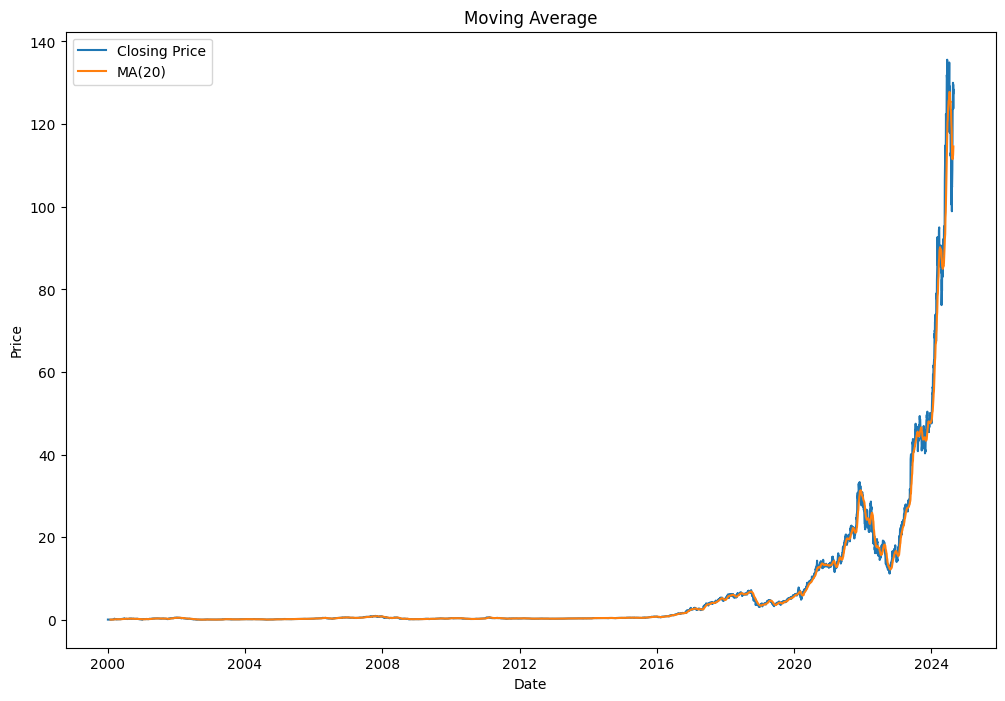

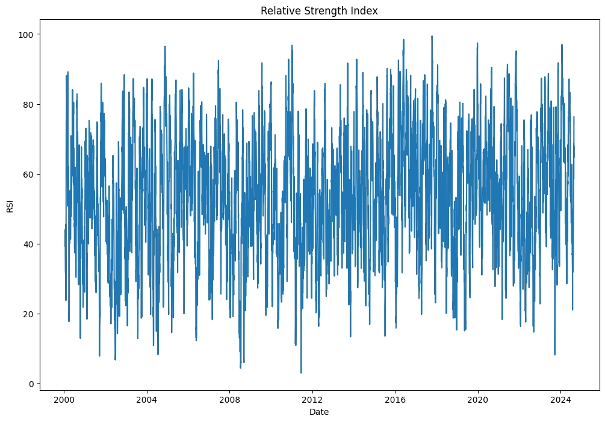

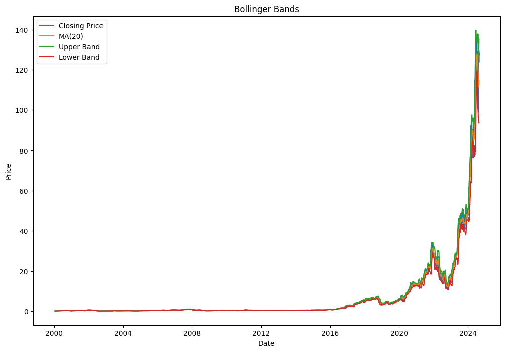

```python
# plot the MA, RSI, and Bollinger Bands
plt.figure(figsize=(12, 8))
plt.plot(historical_data['Date'], historical_data['Close'], label='Closing Price')
plt.plot(historical_data['Date'], historical_data['MA'], label='MA(20)')
plt.legend(loc='upper left')
plt.title('Moving Average')
plt.xlabel('Date')
plt.ylabel('Price')

plt.figure(figsize=(12, 8))
plt.plot(historical_data['Date'], historical_data['RSI'])
plt.title('Relative Strength Index')
plt.xlabel('Date')
plt.ylabel('RSI')

plt.figure(figsize=(12, 8))
plt.plot(historical_data['Date'], historical_data['Close'], label='Closing Price')
plt.plot(historical_data['Date'], historical_data['MA20'], label='MA(20)')
plt.plot(historical_data['Date'], historical_data['UpperBand20'], label='Upper Band')
plt.plot(historical_data['Date'], historical_data['LowerBand20'], label='Lower Band')
plt.legend(loc='upper left')
plt.title('Bollinger Bands')
plt.xlabel('Date')
plt.ylabel('Price')

plt.show()
```

### Volume Indicators

Volume, On Balance Volume (OBV) and Volume Weighted Average Price (VWAP) are also commonly used features in stock price prediction and asset bubble prediction:

```python
# Calculate volume change
historical_data['volume_change'] = historical_data['Volume'].diff()

# Calculate balance volume
historical_data['obv'] = (historical_data['Close'] - historical_data['Open'] > 0).astype(int) * historical_data['Volume']
# Calculate cumulative balance volume
historical_data['obv'] = historical_data['obv'].cumsum()

# Calculate transaction amount
historical_data['trade_amount'] = historical_data['Close'] * historical_data['Volume']
# Calculate volume weighted average price
historical_data['vwap'] = historical_data['trade_amount'].cumsum() / historical_data['Volume'].cumsum()
```

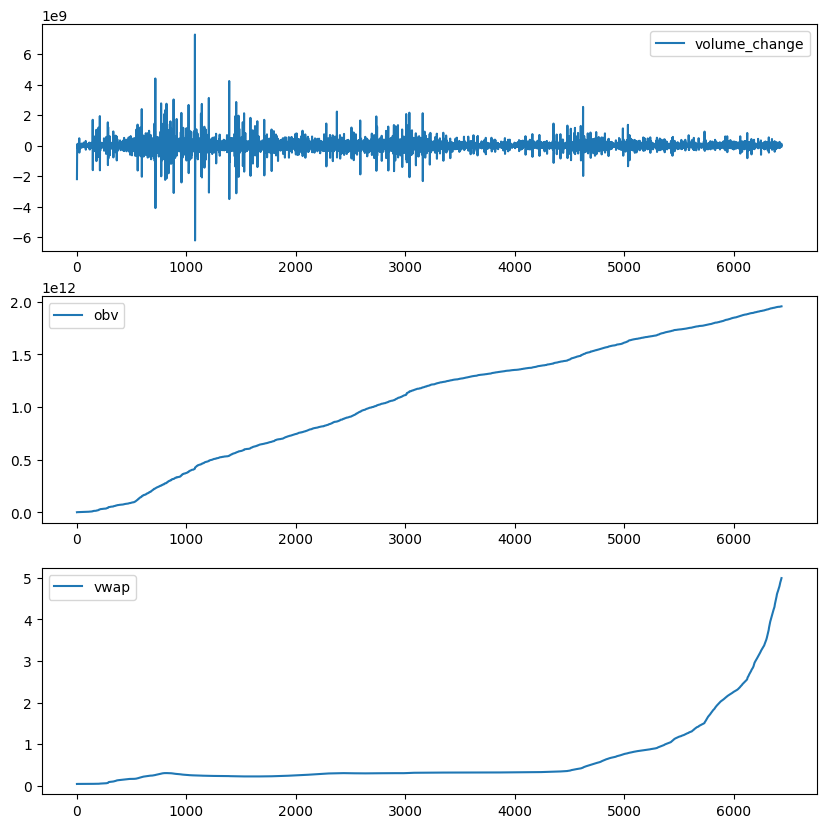

```python
# plot volume change, balance volume, volume weighted average price
fig, axes = plt.subplots(nrows=3, ncols=1, figsize=(10,10))
historical_data.plot(y='volume_change', ax=axes[0])
historical_data.plot(y='obv', ax=axes[1])
historical_data.plot(y='vwap', ax=axes[2])
plt.show()
```